# Reporte técnico - Modelo predicctivo del número de hijos en hogares colombianos

Juan Esteban Cendales Sora - Daniel Escobar David - Alejandro Jiménez Franco - Juan José Sapuyes Pino - Santiago Alexis Valencia Zapata

5/4/2021

# Intoducción

El número de hijos de un hogar puede ser determinante al momento de ofrecer un servicio financiero, por ejemplo, las empresas que prestan servicios pensionales en Colombia consideran el número de hijos al momento de ofrecer el monto total de una pensión, pues, al momento de la persona morir, se espera que la pensión pueda sostener a los hijos del beneficiado hasta que se cumplan ciertos requisitos. Un número mayor de hijos implica para el fondo de pensiones, mayores gastos a largo plazo. De igual manera, en las entidades bancarias, al momento de analizar los factores de riesgo para la entrega de un préstamo, también se tiene en cuenta el número de hijos en el hogar, puesto que una persona que tenga muchos más hijos tiende a gastar más para poder cubrir las necesidades de estos, lo que puede desembocar que en algún momento le sea mucho más difícil pagar el préstamo que se le ofrece en comparación con otra persona que tiene menos hijos o que no los tiene.

Determinar el número de hijos de un hogar en Colombia se convierte en una tarea complicada, puesto que existen grandes diferencias culturales, generacionales, sociales y económicos que modelan la imagen de familia que tienen los colombianos en las diferentes regiones del país, y por consiguiente, el número de hijos de cada hogar (Pachón, 2004).

Con esta motivación, el estudio aquí presentado tiene como finalidad generar un modelo predictivo para el número de hijos de los hogares colombianos, que pueda ser utilizado por empresas que ofrezcan servicios financieros, para que, puedan estimar con una alta precisión, cuál es el número de hijos que tiene un hogar, en caso de que este dato se desconozca o se tengan dudas sobre él, analizando otras características del hogar de la persona que se está analizando.

# Retos

Los principales retos al momento de realizar este modelo predictivo son:

- Identificar las variables de entrada y de salida del modelo
- Encontrar en la fuente de datos, la información que permita construir las respectivas variables de entrada y salida
- Analizar, preprocesar y filtrar los datos obtenidos
- Encontrar la mejor combinación de variables para simplificar las entradas del modelo
- Encontrar el tipo de modelo que mejor se adapte a las condiciones de los datos y a la capacidad del equipo investigador
- Entrenar el modelo y explorar los resultados obtenidos

# Materiales y métodos

Construcción de un modelo descriptivo retrospectivo, con fuente de información secundaria

## Base de datos inicial

Para realizar el análisis de los hogares colombianos y obtener datos con los cuales entrenar el modelo, se recurre a la *Encuesta Nacional de Calidad de Vida* realizada por la *Dirección de Metodología y Producción Estadística - DIMPE* y el *Departamento Administrativo Nacional de Estadística - DANE* realizada en todo el territorio colombiano en el año 2019. Los resultados de esta encuesta recolectan información de los hogares colombianos en un nivel jerárquico de la siguiente manera:

- Viviendas
- Hogares
- Personas

Esto quiere decir que, se realizaron encuestas en viviendas, las cuales cada una podría tener uno o más hogares, los cuales también fueron encuestados de manera individual. Estos a su vez, pueden estar compuestos por una o más personas, las cuales también fueron encuestadas de manera individual.

En este orden de ideas, la base de datos de las respuestas dadas por los colombianos se divide en 15 tablas, según la temática de las preguntas, que se relacionan una a otras según su jerarquía, conectándose por medio de variables ‘llave’. Las tablas son las siguientes

| # | Nombre de la tabla | Tipo tabla | Sección encuesta | Variables | Datos |
| --- | --- | --- | --- | --- | --- |
| 1 | Datos de la vivienda | Vivienda | B | 31 | 93161 |
| 2 | Servicios del hogar | Hogar | C | 59 | 93993 |
| 3 | Tenencia y financiación de la vivienda | Hogar | K | 15 | 93993 |
| 4 | Condiciones de vida del hogar y tenencia de bienes | Hogar | L | 99 | 93993 |
| 5 | Uso de energéticos en el hogar | Hogar | M | 40 | 93993 |
| 6 | Características y composición del hogar | Persona | D | 41 | 289558 |
| 7 | Salud | Persona | E | 98 | 289558 |
| 8 | Atención integral de niños y niñas menores de 5 años | Persona | F | 50 | 22932 |
| 9 | Educación | Persona | G | 53 | 266626 |
| 10 | Fuerza de trabajo | Persona | H | 117 | 230818 |
| 11 | Tecnologías de información y comunicación | Persona | I | 70 | 266626 |
| 12 | Trabajo infantil | Persona | J | 37 | 35808 |
| 13 | Tenencia y financiación de la vivienda (Personal) | Persona | K | 1 | 8597 |
| 14 | Condiciones de vida del hogar y tenencia de bienes I (Personal) | Persona | L | 3 | 1185 |
| 15 | Condiciones de vida del hogar y tenencia de bienes II (Personal) | Persona | L | 1 | 22635 |

Al observar la cantidad de datos de la base, podemos observar que se encuestaron 93161 viviendas, 93993 hogares y 289558 personas. Además de que tenemos hasta 715 posibles variables, sin contar a las variables “llave”, las cuales son:

- Entre Vivienda a Hogar o a Personas: **DIRECTORIO**
- Entre Hogares: **DIRECTORIO** y **SECUENCIA_ENCUESTA**
- Entre Hogares y Personas: **DIRECTORIO** y **SECUENCIA_ENCUESTA** de la tabla de hogares, que en la tabla de personas equivale a **DIRECTORIO** y **SECUENCIA_P**
- Entre personas: **DIRECTORIO**, **SECUENCIA_ENCUESTA** y **SECUENCIA_P**

## Selección de variables y del tipo de modelo

Para generar un modelo que pueda predecir el número de hijos de los hogares colombianos es fundamenteal, filtrar de entre las posibles 715 opciones, el menor número posible de variables que se relacionen con el tema y que nos puedan llevar a una respuesta satisfactoria, para analizarlos y con en base a ellos construir un modelo. El conjunto de datos que tenemos para lograrlo tiene la particularidad de que la variable de salida que estamos buscando no se encuentra de forma explícita en ninguna de las tablas, pero hay diferentes formas de inferirla a partir de los datos que si se tienen, por lo que también hay que definirla.

### Variable de salida (Número de hijos por hogar)

La variable de salida del modelo debe ser el número de hijos por hogar. Para calcularla, se ha tomado la pregunta **P6051** *¿Cuál es el parentesco de … con el jefe o la jefa de este hogar?* de la tabla *Características y composición del hogar*, la cual tiene una serie de respuestas categóricas que se muestran en la siguiente tabla

| Respuesta | Significado |
| --- | --- |
| 1 | Jefe(a) del hogar |
| 2 | Pareja, esposo(a), conyuge, comañero(a) |
| 3 | Hijo(a), hijastro(a) |
| 4 | Nieto(a) |
| 5 | Padre, madre, padrastro, madrastra |
| 6 | Suegro o suegra |
| 7 | Hermano(a), hermanastro(a) |
| 8 | Yerno, nuera |
| 9 | Otro(a) pariente del (de la) jefe(a) |
| 10 | Empleado(a) del servicio doméstico |
| 11 | Parientes del servicio doméstico |
| 12 | Trabajador |
| 13 | Pensionista |
| 14 | Otro(a) no pariente |

Por simplicidad, solo observaremos los hijos que tenga el núcleo familiar principal del hogar, es decir, los hijos directos del Jefe(a) de hogar, cuya respuesta a esta pregunta debe ser 3. A estos se les hace un conteo agrupado por hogar. Además, si el jefe de hogar o su conyuge responde a la pregunta **P5694** de la tabla *Salud*, la cual dice *Si está embarazada actualmente, ¿asiste a control prenatal?*, cuyas opciones de respuesta son:

| Respuesta | Significado |
| --- | --- |
| 1 | Si |
| 2 | No |
| 3 | No está embarazada |

Si responde con la oppción 1 o 2, se asume que este es otro hijo y se le adiciona a la agrupación hecha a partir de la primera pregunta, sin considerar un posible nacimiento múltiple o una interrupción del embarazo.

### Variables de entrada

Como se ha mencionado anteriormente, en Colombia no existe una visión uniforme del concepto de familia, puesto que este puede variar tanto por la posición geográfica del hogar, como por aspectos económicos y socioculturales, entre los cuales destaca la percepción y autopercepción del papel que tiene la mujer dentro de la familia y de la sociedad (Pachón, 2004). La visión de familia y las condiciones socioeconómicas de un hogar influyen directamente en el número de hijos que se puede esperar de ella. Forero y Gamboa (2009) en su estudio acerca del número de hijos no planeados por mujer en Colombia, destaca que factores como el nivel de educación de la mujer, su edad, residencia, estrato socioeconómico, estado marital y su conocimiento y uso de los métodos anticonceptivos, son los factores diferenciadores entre el número de hijos no planificados de una mujer.

Por otra parte, López, Silva y Sarmiento (2010) en su estudio sobre el uso de los servicios maternos en Colombia también destacan el nivel de riqueza, la participación de la mujer en la toma de decisiones del hogar, además del nivel educativo de la pareja, en caso de que la haya, son otros factores importantes para considerar al caracterizar los hogares y el tipo de familias.

Otros estudios similares (Alvis et al., 2010; Torres y Vergara, 2012) también destacan la participación tanto de la mujer, como de su pareja en el mercado laboral, y resaltan la importancia del nivel educativo, la edad y la posición socioeconómica como aspectos que influyen en la planificación familiar, y, por lo tanto, en el número de hijos por hogar. En total, podemos resumir las variables consideradas en estos estudios en la siguiente lista:

- Nivel educativo de la mujer y su pareja
- Edad de la mujer y su pareja
- Residencia del hogar
- Estrato socioeconómico del hogar
- Estado marital del o los jefes de hogar
- Conocimiento y uso de anticonceptivos
- Riqueza
- Participación de la mujer en las decisiones del hogar
- Trabajo de la mujer y su pareja

Se realizó una exploración de las preguntas y variables de la encuesta Nacional de Calidad de Vida del 2019 para relacionar y seleccionar las que se relacionen con las variables expuestas por la literatura. Los resultados los observamos en la siguiente tabla:

| # | Código | Tabla | Pregunta | Tipo | Relación con |
| --- | --- | --- | --- | --- | --- |
| 1 | P6051 | Características y composición del hogar | ¿Cuál es el parentesco con el jefe o la jefa de este hogar? | Categórica | Participación de la mujer en las decisiones del hogar |
| 2 | P6020 | Características y composición del hogar | Sexo | Categórica | Participación de la mujer en las decisiones del hogar |
| 3 | P6040 | Características y composición del hogar | ¿Cuántos años cumplidos tiene? | Numérica discreta | Edad de la mujer y su pareja |
| 4 | P5502 | Características y composición del hogar | (Respecto al estado marital)Actualmente…: | Categórica | Estado marital del o los jefes de hogar |
| 5 | P6240 | Fuerza de trabajo | ¿en que actividad ocupó la mayor parte del tiempo la semana pasada? | Categórica | Trabajo de la mujer y su pareja |
| 6 | I_HOGAR | Servicios del hogar | Ingreso mensual total del hogar | Numérica continua | Riqueza |
| 7 | P1084 | Tecnologías de información y comunicación | ¿Con qué frecuencia utiliza internet (en cualquier lugar y desde cualquier dispositivo)? | Categórica | Conocimiento y uso de anticonceptivos |
| 8 | REGION | Datos de la vivienda | Región | Categórica | Residencia del hogar |
| 9 | P8520S1A1 | Datos de la vivienda | Estrato | Categórica | Estrato socioeconómico del hogar |
| 10 | P8587 | Educación | ¿cuál es el nivel educativo más alto alcanzado y el último año o grado aprobado en este nivel? | Categórica | Nivel educativo de la mujer y su pareja |

Además, también se incluyen las siguientes variables que a consideranción de los investigadores, pueden dar pista de la cantidad de hijos de un hogar, debido a que pueden dar cuenta de cuántas personas la componen, como es el caso de la afilización a salud, pues las familias numerosas pueden tender al régimen subsidiado por ser más económico, el conteo de salas y cuartos, así como la cantidad de personas en el hogar, y el uso de la lavadora, y la cuenta de la energía eléctrica, que puede aumentar mientras más personas compongan el núcleo familiar. Las variables seleccionadas las encontramos en la siguiente tabla:

| # | Código | Tabla | Pregunta | Tipo |
| --- | --- | --- | --- | --- |
| 11 | P6090 | Salud | ¿ Está afiliado(a) (cotizante o beneficiario(a)) a alguna entidad de seguridad social en salud? (Entidad Promotora de Salud - EPS o Entidad Promotora de Salud Subsidiada -EPS-S ) | Categórica |
| 12 | P5000 | Servicios del hogar | Incluyendo sala-comedor ¿de cuántos cuartos en total dispone este hogar? | Numérica discreta |
| 13 | P5010 | Servicios del hogar | ¿en cuántos de esos cuartos (P5000) duermen las personas de este hogar? | Numérica discreta |
| 14 | CANT_PERSONAS_HOGAR | Servicios del hogar | Cantidad de personas en el hogar | Numérica continua |
| 15 | P5510 | Uso de energéticos en el hogar | En promedio, ¿cuántas cargas de ropa lava en su lavadora a la semana? | Categórica |
| 16 | P5018 | Uso de energéticos en el hogar | ¿Cuanto pagaron EL MES PASADO o la última vez por la electricidad consumida? | Continua |
| 17 | P5018S1 | Uso de energéticos en el hogar | ¿a cuántos meses corresponde ese pago (P5018)? | Numérica discreta |

De ahora en adelante, para referirse a las preguntas se hará referencia a la numeración establecida en las tablas anteriores

#### Reinterpretación de las variables de entrada

La contrucción de la base de datos propia para el modelamiento y entrenamiento del modelo predictivo se realizó explorando y reinterpretando algunas de las variables escogidas, para finalmente obtener un conjunto de datos más limpio y fácil de analizar. Para esto se hizo uso de *scripts* de autoria propia escritos en **Python**, los cuales se pueden encontrar en el Repositorio online del proyecto, en la carpeta *codigosPY* https://github.com/juanescendales/TAE-01-NatalidadColombia/tree/main/codigosPY En esta carpeta encontramos el archivo llamado *ReorganizarTablas.py* que se encarga de hacer un llamado a los demás *scripts* de la carpeta, los cuales cada uno se encarga de hacer la extracción de datos de una tabla en particular, siguiendo los procedimientos explicados en los siguientes puntos:

##### 1. ¿Cuál es el parentesco con el jefe o la jefa de este hogar? (P6051)

Opciones de respuesta a la pregunta

| Respuesta | Significado |
| --- | --- |
| 1 | Jefe(a) del hogar |
| 2 | Pareja, esposo(a), conyuge, comañero(a) |
| 3 | Hijo(a), hijastro(a) |
| 4 | Nieto(a) |
| 5 | Padre, madre, padrastro, madrastra |
| 6 | Suegro o suegra |
| 7 | Hermano(a), hermanastro(a) |
| 8 | Yerno, nuera |
| 9 | Otro(a) pariente del (de la) jefe(a) |
| 10 | Empleado(a) del servicio doméstico |
| 11 | Parientes del servicio doméstico |
| 12 | Trabajador |
| 13 | Pensionista |
| 14 | Otro(a) no pariente |

Esta pregunta identifica tanto al Jefe de hogar, que siempre existe para cada hogar, como a la pareja del jefe de hogar, en caso de que esta exista, los cuales se encuentran con el valor respuesta de 1 y 2 respectivamente. A excepción de los que respondan 3, que también son usados en la variable de salida, las otras respuestas no se tendrán en cuenta

##### 2. Sexo (P6020)

Opciones de respuesta a la pregunta

| Respuesta | Significado |
| --- | --- |
| 1 | Hombre |
| 2 | Mujer |

Esta variable, en conjunto con la pregunta 1, permite inferir el sexo tanto del Jefe de hogar, como de su pareja en caso de que exista, para crear dos variables llamadas **Sexo.Jefe** y **Sexo.Conyuge** las cuales tendrán las mismas opciones de respuesta a esta pregunta, y NA en caso de que no exista

##### 3. ¿Cuántos años cumplidos tiene? (P6040)

Esta variable, expresada en años, en conjunto con la pregunta 1, permite inferir la edad tanto del Jefe de hogar, como de su pareja en caso de que exista, para crear dos variables que llamadas **Edad.Jefe** y **Edad.Conyuge** las cuales tendrán el mismo valor literal que esta pregunta, o un NA en caso de que no exista.

##### 4. (Respecto al estado marital)Actualmente…: (P5502)

Opciones de respuesta a la pregunta

| Respuesta | Significado |
| --- | --- |
| 1 | No está casado(a) y vive en pareja hace menos de dos años |
| 2 | No está casado(a) y vive en pareja hace dos años o más |
| 3 | Está viudo(a) |
| 4 | Está separado(a) o divorciado(a) |
| 5 | Está soltero(a) |
| 6 | Está casado(a) |

Al identificar al jefe del hogar con la pregunta 1, también se puede identificar su estado civil o marital, y se lo asignamos al hogar correspondiente con los mismos valores y significados bajo la variable **Tipo.Union**

##### 5. ¿en que actividad ocupó la mayor parte del tiempo la semana pasada? (P6240)

Opciones de respuesta a la pregunta

| Respuesta | Significado |
| --- | --- |
| 1 | Trabajando |
| 2 | Buscando trabajo |
| 3 | Estudiando |
| 4 | Oficios del hogar |
| 5 | Incapacitado permanentemente para trabajar |
| 6 | Otra actividad |

Esta pregunta permite inferir el tipo de actividad laboral tanto del Jefe de hogar como de su conyuge, haciendo uso de las mismas categorías y significados dentro de las variables **Trabajo.Jefe** y **Trabajo.conyuge**

##### 6. Ingreso mensual total del hogar (I_HOGAR)

A cada hogar se le asigna el valor de esta variable, que está expresada en Pesos Colobmianos (COP) y se almacena dentro de la variable **Ingresos.totales**. En caso de que el valor sea nulo o igual a 0, para evitar el ruido, se le asigna un valor equivalente a la media de los valores no nulos, mas un número aleatorio que se encuentre entre la desviación estándar negativa y la desviación estándar positiva.

##### 7. ¿Con qué frecuencia utiliza internet (en cualquier lugar y desde cualquier dispositivo)? (P1084)

Opciones de respuesta a la pregunta y reinterpretación

| Respuesta | Significado | Reiterpretación | Nuevo significado |
| --- | --- | --- | --- |
| 1 | Todos los días de la semana | 2 | Conexión frecuente |
| 2 | Al menos una vez a la semana, pero no cada día | 2 | Conexión frecuente |
| 3 | Al menos una vez al mes, pero no cada semana | 1 | Conexión ocacional |
| 4 | Al menos una vez al año, pero no cada mes | 1 | Conexión ocacional |
| 5 | No utiliza internet | 0 | No se conecta |

Con ayuda de la pregunta 1, se puede identificar qué tan frecuente es el uso de internet, tanto por parte del Jefe de hogar, como de su cónyuge si este existe, reinterpretando sus valores y significados como se muestra en la tabla anterior, y los valores correspondientes se almacenan en las variables **Uso.tecnologia.jefe** y **Uso.tecnologia.conyuge**

##### 8. Región (REGION)

Opciones de respuesta a la pregunta

| Respuesta | Significado |
| --- | --- |
| 1 | Caribe |
| 2 | Oriental |
| 3 | Central |
| 4 | Pacífica(sin valle) |
| 5 | Bogotá |
| 6 | Antioquia |
| 7 | Valle del cauca |
| 8 | San Andrés |
| 9 | Orinoquía - Amazonía |

Esta pregunta ubica a cada hogar en una de las 9 regiones geográficas del país como se indica en la tabla anterior. La respuesta de cada hogar a esta respuesta se almacena en la variable **Region**, sin modificar su interpretación original

##### 9. Estrato (P8520S1A1)

Opciones de respuesta a la pregunta

| Respuesta | Significado |
| --- | --- |
| 1 | Bajo - Bajo |
| 2 | Bajo |
| 3 | Medio - Bajo |
| 4 | Medio |
| 5 | Medio - Alto |
| 6 | Alto |
| 8 | Planta eléctrica |
| 9 | No conoce el estrato o no cuenta con recibo de pago. |
| 0 | Recibos sin estrato o el servicio es pirata |

Originalmente, la pregunta va dirigida a responder el estrato con el que se paga la factura eléctrica, por eso, además de los típicos estrátos del 1 al 6, nos encontramos con numeración de 8 y 0, que se relacionan más al tipo de acceso a la energía con el que cuentan, que con su estrato socioeconómico. A pesar de esto, estas dos categorías se dejaron intactas, pues, a pesar de que no son los valores estándar para los estratos en Colombia, en si mismo no se pueden clasificar dentro de otro estrato con la información que se posee, además, diferenciar a los hogares con estas características particulares puede ser de ayuda en el momento de la construcción del modelo. Por otra parte, los hogares cuyos valores son 9 o que no tienen valor en esta pregunta, que son aproximadamente 7062 hogares, serán descartados de la base de datos final, puesto que no hay forma de clasificarlos sin ambigüedad. Los valores de esta variable quedan almacenados en la columna **Estrato.vivienda**.

##### 10. ¿cuál es el nivel educativo más alto alcanzado y el último año o grado aprobado en este nivel? (P8587)

Opciones de respuesta a la pregunta y reinterpretación

| Respuesta | Significado | Reiterpretación | Nuevo significado |
| --- | --- | --- | --- |
| 1 | Ninguno | 0 | Ninguno |
| 2 | Preescolar | 1 | Educación basica |
| 3 | Básica Primaria (1º - 5º) | 1 | Educación basica |
| 4 | Básica secundaria (6º–9º) | 1 | Educación basica |
| 5 | Media (10º–13º) | 1 | Educación basica |
| 6 | Técnico sin título | 2 | Educación profesional no completa |
| 7 | Técnico con título | 3 | Educación profesional |
| 8 | Tecnológico sin título | 2 | Educación profesional no completa |
| 9 | Tecnológico con título | 3 | Educación profesional |
| 10 | Universitario sin titulo | 2 | Educación profesional no completa |
| 11 | Universitario con titulo | 3 | Educación profesional |
| 12 | Postgrado sin titulo | 3 | Educación profesional |
| 13 | Postgrado con titulo | 3 | Educación profesional |

Esta variable permite identificar el máximo nivel de educación, en conjunto con la pregunta 1, del Jefe de Hogar y de su Cónyuge en caso de que exista. La variable se reinterpreta agrupando las 13 categorías iniciales en 4, como se muestra en la tabla anterior, y se almacena en la columnas **Edu.Jefe** y **Edu.Conyuge**.

##### 11.¿ Está afiliado(a) (cotizante o beneficiario(a)) a alguna entidad de seguridad social en salud? (Entidad Promotora de Salud - EPS o Entidad Promotora de Salud Subsidiada -EPS-S ) (P6090)

Opciones de respuesta a la pregunta

| Respuesta | Significado |
| --- | --- |
| 1 | Sí |
| 2 | No |
| 9 | No sabe, no informa |

Las respuestas de esta pregunta se almacenan con los mismos valores y significados en la columna **Afiliacion.salud**. Posteriormente, se eliminan los registros de los hogares que dan como respuesta a esta pregunta con un 9, los cuales son 630 datos en total.

##### 12. Incluyendo sala-comedor ¿de cuántos cuartos en total dispone este hogar? (P5000)

Esta variable, medida en número de cuartos, se guarda con su valor original correspondiente a cada hogar, dentro de la columna **N.cuartos**.

##### 13. ¿en cuántos de esos cuartos (Pregunta 12) duermen las personas de este hogar? (P5010 )

Esta variable, medida en número de cuartos, se guarda con su valor original correspondiente a cada hogar, dentro de la columna **N.cuartos.dormir**.

##### 14. Cantidad de personas en el hogar (CANT_PERSONAS_HOGAR)

Esta variable, medida en número de personas, se guarda con su valor original correspondiente a cada hogar, dentro de la columna **cantidad.de.personas**.

##### 15. En promedio, ¿cuántas cargas de ropa lava en su lavadora a la semana? (P5510)

Opciones de respuesta a la pregunta

| Respuesta | Significado | Reiterpretación | Nuevo significado |
| --- | --- | --- | --- |
| NA | No usa o no tiene lavadora | 0 | No usa o no tiene lavadora |
| 1 | Una carga o menos | 1 | Una carga o menos |
| 2 | 2 a 4 cargas | 2 | 2 a 4 cargas |
| 3 | 5 a 9 cargas | 3 | 5 a 9 cargas |
| 4 | 10 a 15 cargas | 4 | 10 a 15 cargas |
| 5 | Más de 15 cargas | 5 | Más de 15 cargas |

La reinterpretación de esta variable solo consta de redefinir los valores NA, en 0, lo que significa que en el hogar no se tiene o no se hace uso de la lavadora, las otras opciones de respuesta se mantienen intactas. Luego, los resultados para cada hogar son almacenados en la columna **N.usos.lavadora**.

##### 16. ¿Cuanto pagaron EL MES PASADO o la última vez por la electricidad consumida? (P5018) y 17. ¿a cuántos meses corresponde ese pago (Pregunta 16)? (P5018S1)

La variable 16, medida en Pesos Colombianos (COP) y la 17, medida en Meses, se complementan para calcular el pago mensual que se hace, por hogar, de la electricidad consumida, dividiendo el valor pagado el último mes sobre la cantidad de meses a la que corresponde. En caso de que esta operación no se pueda ejecutar, se deja en 0, y posteriormente se les calcula un valor con base en la suma de la media mas un número random entre la desviación estándar negativa y la desviación estándar positiva.Esto para evitar ruido. Finalmente, esta variable calculada se almacena en la columna **Valor.Electricidad**, la cual se mide en COP/meses.

#### Conjunto de datos filtrado

| Nombre de variable | Tipo | Explicación |
| --- | --- | --- |
| Código | Categorica | Identificador único de un hogar |
| Hijos | Numérica discreta | Número de hijos del hogar |
| Sexo.Jefe | Categórica | Sexo del jefe de hogar |
| Sexo.Conyuge | Categórica | Sexo del conyuge del jefe de hogar |
| Tipo.Union | Categórica | Estado civil del jefe de hogar |
| Edad.Jefe | Continua | Años cumplidos del jefe de hogar |
| Edad.Conyuge | Continua | Años cumplidos del conyuge del jefe de hogar |
| Region | Categórica | REgión de Colombia en la cual se ubica la vivienda del hogar |
| Cantidad.de.personas | Discreta | Total personas que viven en el hogar |
| Estrato.vivienda | Categórica | Estrato socioeconómico indicado en la factura de servicios en la que se cobra la energía |
| Trabajo.Jefe | Categórica | Actividad que realiza el jefe de hogar |
| Trabajo.conyuge | Categórica | Actividad que realiza el conyuge del jefe de hogar |
| Ingresos.totales | Continua | Ingresos totales del hogar en COP |
| Uso.tecnologia.Jefe | Categórica | Frecuencia de conexión a internet del jefe de hogar |
| Uso.tecnologia.conyuge | Categórica | Frecuencia de conexión a internet del conyuge del jefe de hogar |
| Edu.Jefe | categórica | Máximo nivel de educación alcanzado por el jefe de hogar |
| Edu.Conyuge | Categórica | Máximo nivel de educación alcanzado por el conyuge del jefe de hogar |
| Afiliacion.salud | Categórica | Responde si está afiliado a la salud o no |
| N.cuartos | Numérica discreta | Número de cuartos de la vivienda del hogar |
| N.cuartos.dormir | Numérica discreta | Número de cuartos de la vivienda del hogar usados como habitaciones para dormir |
| Valor.Electricidad | Continua | Valor en COP/mes del recibo por el uso de la electricidad en el hogar |
| N.usos.Lavadora | Categórica | Número de cargas de ropa que se lavan haciendo uso de la lavadora por semana en el hogar |

```r
#rm(list=ls())
library(knitr)
library(caret)
library(tidyr)
library(dplyr)
library(ggplot2)
library(kableExtra)
library(corrplot)
library(glmnet)
```

```r
# Función para crear tablas en el reporte divididas en dos partes
tabla_dividida <- function(tabla) {

  all <- list()
  rows <- seq_len(nrow(tabla) %/% 2) #Separamos las filas en 2 partes
  rows <- list(rows,-rows)
  for (i in 1:2) {

    a <- tabla[rows[[i]],] #Seleccionamos los datos de cada una de las partes
    names <- row.names(tabla)[rows[[i]]] #Obtenemos los nombres
    a <- cbind(names,a) #Juntamos los datos y los nombres
    colnames(a) <- c("Varaible","Tipo") #Asignamos los nombres de las columnas

    all[[i]] <- a #Asignamos un conjunto de datos en la posición i

  }


  kable(all)%>% kable_styling(latex_options = "hold_position") #Imprimimos la tabla
}
```

```r
#Traemos y leemos los datos del conjunto de datos
datos_originales <- read.csv2(file('./DatosCSVProcesados/DatosCompletosING.csv', encoding="UTF-8"))
```

## Analisis Exploratorio

En el siguiente informe, se realiza una exploración inicial de los datos para encontrar las pósibles relaciones que puedan existir entre la variable respuesta *Hijos* y las demás covariables que representan las caracteristicas del hogar.

### Recodificación y Contextualización De Los Datos

En la construcción de la base de datos encontramos que hay multiples tipos de variables que se pueden utilizar tales como: variables numericas, variables ordinales y variables nominales.

Despúes de cargada la base, se encuentra que el tipo de cada variables no necesariamente es el correcto. Esto lo podemos observar en la siguiente tabla:

```r
#Jeneramos un dataframe con los datos y su clase de dato
tipo_datos <- data.frame(sapply(datos_originales,class))
names(tipo_datos) <- "Tipo"
tabla_dividida(tipo_datos)
```

| Varaible | Tipo |
| --- | --- |
| Codigo | character |
| Hijos | integer |
| Sexo.Jefe | integer |
| Sexo.Conyuge | integer |
| Tipo.Union | integer |
| Edad.Jefe | integer |
| Edad.Conyuge | integer |
| Region | integer |
| Cantidad.de.personas | integer |
| Estrato.vivienda | integer |
| Trabajo.Jefe | integer |

| Varaible | Tipo |
| --- | --- |
| Trabajo.conyuge | integer |
| Ingresos.totales | integer |
| Uso.tecnologia.Jefe | integer |
| Uso.tecnologia.conyuge | integer |
| Edu.Jefe | integer |
| Edu.Conyuge | integer |
| Afiliacion.salud | integer |
| N.cuartos | integer |
| N.cuartos.dormir | integer |
| Valor.Electricidad | integer |
| N.usos.Lavadora | integer |

A continuación se recodifica cada variable en su tipo correcto. Los resultados son los siguientes:

```r
#Quitamos el identificador único, pues este no nos interesa
datos_originales$Codigo <- NULL

#Definimos un vector con los nombres de las variables categóricas
variables_categoricas <- c(
  'Sexo.Jefe',
  'Sexo.Conyuge',
  'Tipo.Union',
  'Region',
  'Estrato.vivienda',
  'Trabajo.Jefe',
  'Trabajo.conyuge',
  'Uso.tecnologia.Jefe',
  'Uso.tecnologia.conyuge',
  'Edu.Jefe',
  'Edu.Conyuge',
  'Afiliacion.salud',
  'N.usos.Lavadora'
  )

#Creamos un data frame con las variables categóricas
datos_categoricos <- datos_originales %>%
  select(all_of(variables_categoricas)) %>%
  mutate_if(is.numeric,as.factor)

#Creamos un data frame excluyendo las variables categóricas
datos_numericos <- datos_originales %>%
  select(-all_of(variables_categoricas))

#Juntamos ambos data frames
datos_tipados <- cbind(datos_numericos,datos_categoricos)

#Jeneramos un dataframe con los datos y su clase de dato
tipo_datos <- data.frame(sapply(datos_tipados,class))
names(tipo_datos) <- "Tipo"
tabla_dividida(tipo_datos)
```

| Varaible | Tipo |
| --- | --- |
| Hijos | integer |
| Edad.Jefe | integer |
| Edad.Conyuge | integer |
| Cantidad.de.personas | integer |
| Ingresos.totales | integer |
| N.cuartos | integer |
| N.cuartos.dormir | integer |
| Valor.Electricidad | integer |
| Sexo.Jefe | factor |
| Sexo.Conyuge | factor |

| Varaible | Tipo |
| --- | --- |
| Tipo.Union | factor |
| Region | factor |
| Estrato.vivienda | factor |
| Trabajo.Jefe | factor |
| Trabajo.conyuge | factor |
| Uso.tecnologia.Jefe | factor |
| Uso.tecnologia.conyuge | factor |
| Edu.Jefe | factor |
| Edu.Conyuge | factor |
| Afiliacion.salud | factor |
| N.usos.Lavadora | factor |

Finalmente los datos se encuentras bien codificados.Y podemos empezar la exploración de las variables

```r
nombre_variables_numericas=c(
  'Hijos',
  'Edad del jefe de hogar',
  'Edad del cónyuge del jefe de hogar',
  'Personas del hogar',
  'Ingresos totales del hogar (COP)',
  'Número de cuartos',
  'Número de cuartos usados para dormir',
  'Valor factura electricidad (COP)'

  )

nombre_variables_categoricas=c(
  'Sexo jefe de hogar',
  'Sexo del conyuje',
  'Estado civil del jefe',
  'Región dónde se ubica el hogar',
  'Estrato de vivienda',
  'Ocupación del jefe de hogar',
  'Ocupación del conyuge',
  'Uso de internet jefe de hogar',
  'Uso de internet conyuge',
  'Nivel de educación jefe de hogar',
  'Nivel de educación cónyuge',
  'Afiliación a una EPS',
  'Usos de la lavadora'
)

#Calculamos las desviaciones estándar sin contar los NA
desviaciones_estandar <- t(apply(datos_numericos,2,sd, na.rm=TRUE))
colnames(desviaciones_estandar)<-nombre_variables_numericas
desviaciones_estandar<-t(desviaciones_estandar)
#Realizamos un summary de las variables numéricas
descripcion_variables_numericas <- summary(datos_numericos)
colnames(descripcion_variables_numericas)<-nombre_variables_numericas
descripcion_variables_numericas<-t(descripcion_variables_numericas)
#Realizamos un summary de las variables categóricas
descripcion_variables_categoricas<-summary(datos_categoricos)
colnames(descripcion_variables_categoricas)<-nombre_variables_categoricas
descripcion_variables_categoricas<-t(descripcion_variables_categoricas)

#A todos les aplicamos t() para que la tabla quede transpuesta y se vea mejor

kable(descripcion_variables_numericas, caption='Medidas de localización variables numéricas')
```

Medidas de localización variables numéricas

| Hijos | Min. : 0.000 | 1st Qu.: 0.000 | Median : 1.000 | Mean : 1.125 | 3rd Qu.: 2.000 | Max. :11.000 | NA |
| --- | --- | --- | --- | --- | --- | --- | --- |
| Edad del jefe de hogar | Min. : 13.00 | 1st Qu.: 36.00 | Median : 49.00 | Mean : 49.13 | 3rd Qu.: 61.00 | Max. :106.00 | NA |
| Edad del cónyuge del jefe de hogar | Min. : 12.00 | 1st Qu.: 32.00 | Median : 43.00 | Mean : 44.16 | 3rd Qu.: 55.00 | Max. :107.00 | NA’s :37647 |
| Personas del hogar | Min. : 1.00 | 1st Qu.: 2.00 | Median : 3.00 | Mean : 3.08 | 3rd Qu.: 4.00 | Max. :19.00 | NA |
| Ingresos totales del hogar (COP) | Min. : 0 | 1st Qu.: 600000 | Median : 1089606 | Mean : 1831282 | 3rd Qu.: 2000000 | Max. :284600000 | NA |
| Número de cuartos | Min. : 1.000 | 1st Qu.: 2.000 | Median : 3.000 | Mean : 3.149 | 3rd Qu.: 4.000 | Max. :16.000 | NA |
| Número de cuartos usados para dormir | Min. :1.000 | 1st Qu.:1.000 | Median :2.000 | Mean :1.834 | 3rd Qu.:2.000 | Max. :8.000 | NA |
| Valor factura electricidad (COP) | Min. : 0 | 1st Qu.: 20000 | Median : 35000 | Mean : 51639 | 3rd Qu.: 63900 | Max. :1000000 | NA |

```r
kable(desviaciones_estandar, caption = 'Desviaciones estándas variables numéricas')
```

Desviaciones estándas variables numéricas

| Hijos | 1.178334e+00 |
| --- | --- |
| Edad del jefe de hogar | 1.633028e+01 |
| Edad del cónyuge del jefe de hogar | 1.515462e+01 |
| Personas del hogar | 1.672211e+00 |
| Ingresos totales del hogar (COP) | 3.031752e+06 |
| Número de cuartos | 1.136498e+00 |
| Número de cuartos usados para dormir | 8.425557e-01 |
| Valor factura electricidad (COP) | 6.023938e+04 |

```r
kable(descripcion_variables_categoricas, caption='Exploración inicial variables categóricas')
```

Exploración inicial variables categóricas

| Sexo jefe de hogar | 1:54242 | 2:32502 | NA | NA | NA | NA | NA |
| --- | --- | --- | --- | --- | --- | --- | --- |
| Sexo del conyuje | 1 : 7989 | 2 :41108 | NA’s:37647 | NA | NA | NA | NA |
| Estado civil del jefe | 1: 2141 | 2:30228 | 3: 7482 | 4:14825 | 5:11205 | 6:20863 | NA |
| Región dónde se ubica el hogar | 3 :19488 | 1 :18995 | 2 :16265 | 9 :13244 | 4 : 8715 | 6 : 3607 | (Other): 6430 |
| Estrato de vivienda | 1 :44972 | 2 :23578 | 3 : 7956 | 0 : 3980 | 4 : 2419 | 8 : 1997 | (Other): 1842 |
| Ocupación del jefe de hogar | 1:58216 | 2: 2777 | 3: 728 | 4:18728 | 5: 2960 | 6: 3335 | NA |
| Ocupación del conyuge | 1 :16559 | 2 : 884 | 3 : 431 | 4 :29409 | 5 : 928 | 6 : 886 | NA’s:37647 |
| Uso de internet jefe de hogar | 0:47060 | 1: 1905 | 2:37779 | NA | NA | NA | NA |
| Uso de internet conyuge | 0 :25385 | 1 : 1273 | 2 :22439 | NA’s:37647 | NA | NA | NA |
| Nivel de educación jefe de hogar | 0: 7155 | 1:62489 | 2: 1180 | 3:15920 | NA | NA | NA |
| Nivel de educación cónyuge | 0 : 3312 | 1 :36111 | 2 : 645 | 3 : 9029 | NA’s:37647 | NA | NA |
| Afiliación a una EPS | 1:81847 | 2: 4897 | NA | NA | NA | NA | NA |
| Usos de la lavadora | 0:45663 | 1:12171 | 2:23518 | 3: 4615 | 4: 668 | 5: 109 | NA |

### % NA

Ahora, se procede a encontrar el porcentaje de valores *NA* en cada variable, ya que esto puede ser bastante significativo en procesos posteriores como el ajustar un modelo o seleccionar variables de importancias. La tabla resultante es la siguiente:

```r
#Buscamos los NA's y los guardamos
NAs <- apply(datos_tipados, 2, is.na)

#Calculamos el porcentaje de NA's con respecto al total de datos, por variable
suma_NAs <- data.frame(apply(NAs, 2, sum)/nrow(datos_tipados))
names(suma_NAs) <- "% NA"
tabla_dividida(suma_NAs*100)
```

| Varaible | Tipo |
| --- | --- |
| Hijos | 0 |
| Edad.Jefe | 0 |
| Edad.Conyuge | 43.4001198930185 |
| Cantidad.de.personas | 0 |
| Ingresos.totales | 0 |
| N.cuartos | 0 |
| N.cuartos.dormir | 0 |
| Valor.Electricidad | 0 |
| Sexo.Jefe | 0 |
| Sexo.Conyuge | 43.4001198930185 |

| Varaible | Tipo |
| --- | --- |
| Tipo.Union | 0 |
| Region | 0 |
| Estrato.vivienda | 0 |
| Trabajo.Jefe | 0 |
| Trabajo.conyuge | 43.4001198930185 |
| Uso.tecnologia.Jefe | 0 |
| Uso.tecnologia.conyuge | 43.4001198930185 |
| Edu.Jefe | 0 |
| Edu.Conyuge | 43.4001198930185 |
| Afiliacion.salud | 0 |
| N.usos.Lavadora | 0 |

Las variables que representan información del cónyuge tienen un $43.4\%$ de valores faltantes. Lo anterior se puede deber a que muy probablemente sean hogares en los que el jefe del hogar sea soltero, viudo, etc. Debido a que el porcentaje de NA’s es tan significativo en las variables relacionadas al cónyuge, se opta por prescindir de ellas.

```r
#Definimos un vector con los nombres de las variables categóricas
variables_del_conyuge <- c(
  'Edad.Conyuge',
  'Sexo.Conyuge',
  'Trabajo.conyuge',
  'Uso.tecnologia.conyuge',
  'Edu.Conyuge'
  )

#Borramos las columnas correspondientes a los datos del cónyuge
datos_sin_conyuge <- datos_tipados %>%
  select(-all_of(variables_del_conyuge))
```

### Distribución Variable Respuesta

Inicialmente, observamos como esta distribuida la variable respuesta ya que esto puede ser de vital importancia en los análisis posteriores.

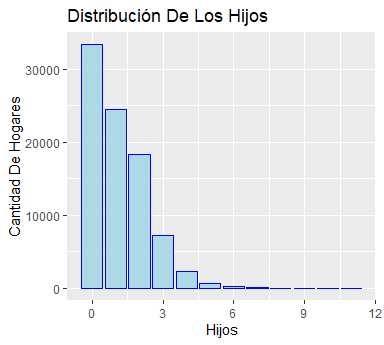

```r
ggplot(datos_sin_conyuge,aes(x=Hijos))+geom_bar(color="blue",fill="lightblue")+labs(title = "Distribución De Los Hijos")+ylab("Cantidad De Hogares")
```

La cantidad de los hijos en los hogares que más predomia es 0, es decir que no hay hijos, después de esto la cantidad de hijos en los hogares decae. A partir de esto, se infiere que es más frecuente no encontrar hijos o encontrar al menos uno, y que es menos frecuente encontrar más de uno. Esto también implica que los datos se encuentran desbalanceados respecto a ciertas cantidades de hijos.

### Relaciones Variable Respuesta y Covariables

Ahora se procede a analizar las posibles relaciones que existan entre la variable respuesta y las covariables, esto ayudara a determinar que variables podrán contribuir a explicar la variabilidad de las variable respuesta.

#### Edad Del Jefe

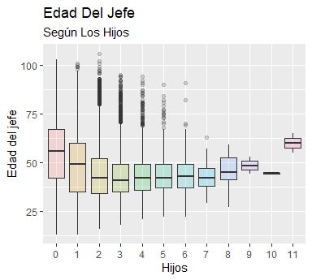

```r
ggplot(datos_sin_conyuge,aes(x=factor(Hijos),y=Edad.Jefe, fill=factor(Hijos)))+geom_boxplot(alpha=0.2)+labs(title = "Edad Del Jefe",subtitle = "Según Los Hijos")+ylab("Edad del jefe")+xlab("Hijos")+theme(legend.position="none")
```

Cuando en el hogar no hay hijos o hay a lo más 1, la edad del jefe del hogar parece variar bastante, mientras que para los hogares donde hay más de 1 hijos, en general, la edades no presentan mayores variaciones. De lo anterior se puede decir, que la edad del jefe puede influir al momento de determinar la cantidad de hijos que se encuentra en el hogar.

#### Cantidad De Personas

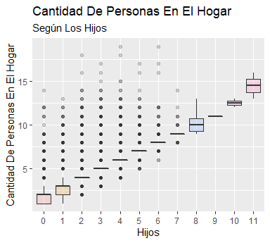

```r
ggplot(datos_sin_conyuge,aes(x=factor(Hijos),y=Cantidad.de.personas, fill=factor(Hijos)))+geom_boxplot(alpha=0.2)+labs(title = "Cantidad De Personas En El Hogar",subtitle = "Según Los Hijos")+ylab("Cantidad De Personas En El Hogar")+xlab("Hijos")+theme(legend.position="none")
```

En general es de esperar que entre mayor sea la cantidad de personas en el hogar, mayor sea el numero de hijos en esta. De este modo, parece que la cantidad de personas en el hogar influye positivamente en el numero de hijos.

#### Estrato De La Vivienda

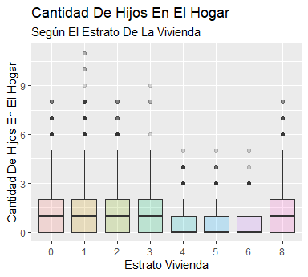

```r
ggplot(datos_sin_conyuge,aes(x=factor(Estrato.vivienda),y=Hijos, fill=factor(Estrato.vivienda)))+geom_boxplot(alpha=0.2)+labs(title = "Cantidad De Hijos En El Hogar",subtitle = "Según El Estrato De La Vivienda")+ylab("Cantidad De Hijos En El Hogar")+xlab("Estrato Vivienda")+theme(legend.position="none")
```

#### Ingresos Totales

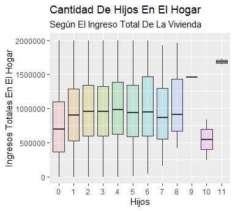

```r
ggplot(datos_sin_conyuge,aes(x=factor(Hijos),y=Ingresos.totales, fill=factor(Hijos)))+geom_boxplot(alpha=0.2)+labs(title = "Cantidad De Hijos En El Hogar",subtitle = "Según El Ingreso Total De La Vivienda")+ylab("Ingresos Totales En El Hogar")+xlab("Hijos")+theme(legend.position="none")+ylim(c(0,2000000))
```

Los ingresos totales de los hogares parecen variar mucho, aunque sus valores se solapan bastante, es posible que los ingresos, puedan influir de manera directa en la cantidad de hijos que se puedan encontrar en él.

#### Numero De Cuartos

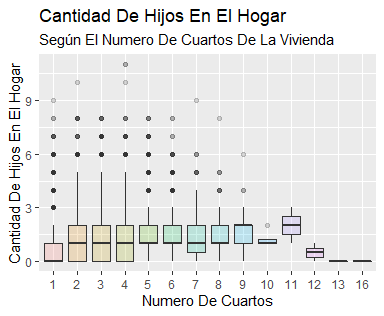

```r
ggplot(datos_sin_conyuge,aes(x=factor(N.cuartos),y=Hijos, fill=factor(N.cuartos)))+geom_boxplot(alpha=0.2)+labs(title = "Cantidad De Hijos En El Hogar",subtitle = "Según El Numero De Cuartos De La Vivienda")+ylab("Cantidad De Hijos En El Hogar")+xlab("Numero De Cuartos")+theme(legend.position="none")
```

No necesariamente si hay más cuartos en un hogar se van a encontrar más hijos en este, pero posiblemente si exista algún tipo de variación. Por lo tanto no podemos asegurar con certeza que en numero de cuartos en el hogar influya en el numero de hijos que se encuentren en el.

#### Numero De Cuartos

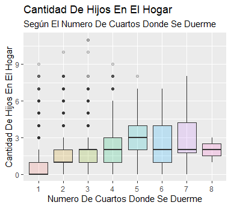

```r
ggplot(datos_sin_conyuge,aes(x=factor(N.cuartos.dormir),y=Hijos, fill=factor(N.cuartos.dormir)))+geom_boxplot(alpha=0.2)+labs(title = "Cantidad De Hijos En El Hogar",subtitle = "Según El Numero De Cuartos Donde Se Duerme")+ylab("Cantidad De Hijos En El Hogar")+xlab("Numero De Cuartos Donde Se Duerme")+theme(legend.position="none")
```

Sutilmente se muestra un patron, aunque no muy fuerte, de que a medida en que el numero de cuartos donde se duerme en el hogar aumenta, tambien lo hace la cantidad de hijos que se encuentran en el. De este modo se infiere que muy probablemnte el numero de cuartos donde se duerme en el hogar ayude a explicar la variabilidad de la cantidad de hijos que se encuentren en el.

#### Valor Electricidad

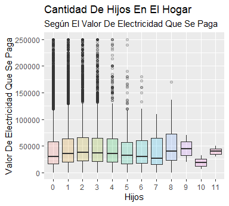

```r
ggplot(datos_sin_conyuge,aes(x=factor(Hijos),y=Valor.Electricidad, fill=factor(Hijos)))+geom_boxplot(alpha=0.2)+labs(title = "Cantidad De Hijos En El Hogar",subtitle = "Según El Valor De Electricidad Que Se Paga")+ylab("Valor De Electricidad Que Se Paga")+xlab("Hijos")+theme(legend.position="none")+ylim(c(0,250000))
```

No se observan patrones ni negativos ni positivos en relación al cambio de los hijos que se encuentren en el hogar. De este modo el valor que se paga de electricidad no influye directamente con el numero de hijos que se encuentre en el hogar.

#### Numero Usos Lavadora

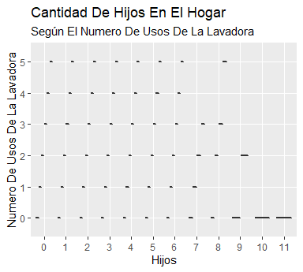

```r
ggplot(datos_sin_conyuge,aes(x=factor(Hijos),y=N.usos.Lavadora, fill=factor(Hijos)))+geom_boxplot(alpha=0.2)+labs(title = "Cantidad De Hijos En El Hogar",subtitle = "Según El Numero De Usos De La Lavadora")+ylab("Numero De Usos De La Lavadora")+xlab("Hijos")+theme(legend.position="none")
```

En general no se observan patrones muy claros en que existan algun tipo de relación entre las variables. Por lo tanto, decimos que el numero de usos de la lavadora no influye en la cantidad de hijos que se puedan encontrar en un hogar.

### Correlaciones

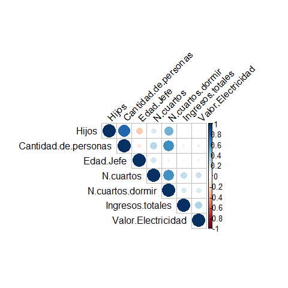

```r
#Generamos un gráfico de correlaciones entre las variables sin conyuge, filtrando las que sean numéricas
corrplot(cor(datos_sin_conyuge %>% select_if(is.numeric)), type = "upper", order = "hclust", tl.col = "black", tl.srt = 45)
```

Las variables que tiene relaciones lineales más fuertes con la variable *Hijos*, son: *Cantidad.de.personas*, *N.cuartos.dormir* y *Edad.Jefe*. Por lo anterior estas 3 variable son candidatas a ser consideradas dentro de un modelo incial.

#### Sexo Del Jefe

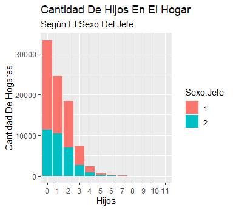

```r
ggplot(datos_sin_conyuge,aes(x=factor(Hijos), fill=Sexo.Jefe))+geom_bar()+labs(title = "Cantidad De Hijos En El Hogar",subtitle = "Según El Sexo Del Jefe")+ylab("Cantidad De Hogares")+xlab("Hijos")
```

Sutilmente se observa una diferencia entre los hijos del hogar cuando el jefe del hogar en hombre o mujer. Por lo anterior podemos decir que el sexo del jefe del hogar puede ayudar a explicar la variabilidad del numero de hijos en un hogar.

#### Tipo De Union

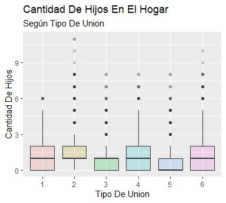

```r
ggplot(datos_sin_conyuge,aes(x=Tipo.Union,y=Hijos, fill=Tipo.Union))+geom_boxplot(alpha=0.2)+labs(title = "Cantidad De Hijos En El Hogar",subtitle = "Según Tipo De Union")+ylab("Cantidad De Hijos")+xlab("Tipo De Union")+theme(legend.position="none")
```

#### Region

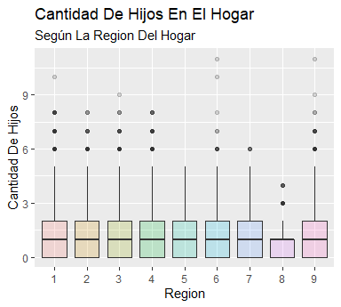

```r
ggplot(datos_sin_conyuge,aes(x=Region,y=Hijos, fill=Region))+geom_boxplot(alpha=0.2)+labs(title = "Cantidad De Hijos En El Hogar",subtitle = "Según La Region Del Hogar")+ylab("Cantidad De Hijos")+xlab("Region")+theme(legend.position="none")
```

Se observa claramente que la cantidad de hijos en el hogar es independiente de la region en la cual se encuentre la vivienda. Se concluye que la region no es una variable que influya en la cantidad de hijos que se encuentren en un hogar.

#### Trabajo Jefe

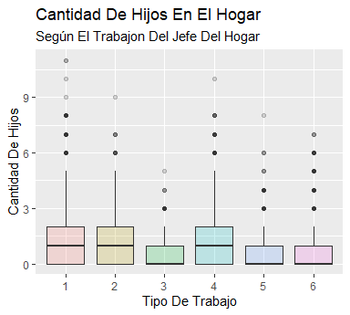

```r
ggplot(datos_sin_conyuge,aes(x=Trabajo.Jefe,y=Hijos, fill=Trabajo.Jefe))+geom_boxplot(alpha=0.2)+labs(title = "Cantidad De Hijos En El Hogar",subtitle = "Según El Trabajon Del Jefe Del Hogar")+ylab("Cantidad De Hijos")+xlab("Tipo De Trabajo")+theme(legend.position="none")
```

No parece haber una relación muy clara entre el tipo de trabajo del jefe del hogar y la cantidad de hijos que se encuentren en el hogar. Por lo anterior, no es recomendable suguerir que el tipo de trabajo del jefe de hogar influya en la cantidad de hijos en el.

#### Uso De Tecnologia

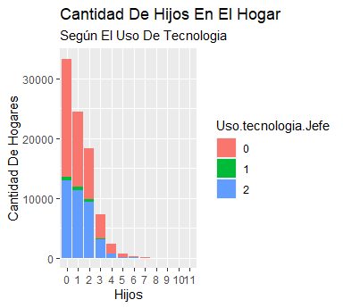

```r
ggplot(datos_sin_conyuge,aes(x=factor(Hijos), fill=Uso.tecnologia.Jefe))+geom_bar()+labs(title = "Cantidad De Hijos En El Hogar",subtitle = "Según El Uso De Tecnologia")+ylab("Cantidad De Hogares")+xlab("Hijos")
```

Claramente se observa que el numero de hijos cambia dependiendo el uso de tecnologia que tenga el jefe del hogar. Por lo tanto, es muy probable que la variable *Uso.tecnologia.Jefe* ayude a explicar la variabilidad de la cantidad de hijos en un hogar.

#### Educación Jefe

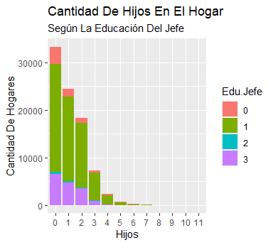

```r
ggplot(datos_sin_conyuge,aes(x=factor(Hijos), fill=Edu.Jefe))+geom_bar()+labs(title = "Cantidad De Hijos En El Hogar",subtitle = "Según La Educación Del Jefe")+ylab("Cantidad De Hogares")+xlab("Hijos")
```

Es notable el cambio en la cantidad de hogares en los que se encuentran ciertas cantidades del hijos según la educación que tenga el jefe del hogar. Dicho esto, es importante considera la variable *Edu.Jefe* para poder explicar el numero de hijos que se encuentren en el hogar.

#### Afiliación Salud

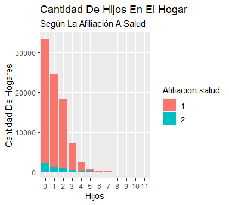

```r
ggplot(datos_sin_conyuge,aes(x=factor(Hijos), fill=Afiliacion.salud))+geom_bar()+labs(title = "Cantidad De Hijos En El Hogar",subtitle = "Según La Afiliación A Salud")+ylab("Cantidad De Hogares")+xlab("Hijos")
```

No se observa que la afiliación a salud determine o segmente fuertemente la cantidad de hijos que se encuentren en un hogar. Por lo tanto la variable *Afiliacion.salud* no ayuda a determinar la cantidad de hijos que se encuentren en un hogar,

### Concluciones Analisis Exploratorio

Por el análisis anterior, se consideran las siguientes variables para ajustar un modelo que prediga el numero de hijos que se encuentran en un hogar:

- Edad.Jefe
- Cantidad.de.personas
- N.cuartos.dormir
- Ingresos.totales
- Valor.Electricidad
- Tipo.Union
- Trabajo.Jefe
- Uso.tecnologia.Jefe
- Sexo.Jefe
- Edu.Jefe

Estas variables muy probablemente nos ayuden a ajustar un modelo predictivo que funcione correctamente.

```r
#Definimos un vector con los nombres de las variables elegidas, incluyendo Hijos
variables_elegidas <- c(
  'Edad.Jefe',
  'Cantidad.de.personas',
  'N.cuartos.dormir',
  'Ingresos.totales',
  'Valor.Electricidad',
  'Tipo.Union',
  'Trabajo.Jefe',
  'Uso.tecnologia.Jefe',
  'Sexo.Jefe',
  'Edu.Jefe',
  'Hijos'
  )

#Generamos un nuevo dataframe con las variables finales
datos_finales <- datos_sin_conyuge %>%
  select(all_of(variables_elegidas))
```

## Elección y construcción del modelo

La elección del modelo se basa en los datos finales obtenidos. Se consideran elementos como la cantidad de datos y el tipo de variable de salida, además de las limitaciones de computación del equipo investigador.

```r
#Generamos datos para caracterizar los datos
caracterizacion_datos <- data.frame(
  'Cantidad de datos' = c(dim(datos_finales)[1]),
  'Tipo de dato de salida' = c(class(datos_finales$Hijos)),
  'max' = c(max(datos_finales$Hijos)),
  'mix' = c(min(datos_finales$Hijos))
)
#Definimos los nombres del data.frame
nombres_caracterizacion_datos <-c('Cantidad de datos','Tipo de dato de salida', 'Dato máximo de la salida', 'Dato mínimo de la salida')
#Cambiamos los nombres y transponemos
colnames(caracterizacion_datos)<-nombres_caracterizacion_datos
caracterizacion_datos<-t(caracterizacion_datos)

kable(caracterizacion_datos, caption = 'Información de los datos', col.names = c('Valor'))
```

Información de los datos

|  | Valor |
| --- | --- |
| Cantidad de datos | 86744 |
| Tipo de dato de salida | integer |
| Dato máximo de la salida | 11 |
| Dato mínimo de la salida | 0 |

La cantidad de datos, en términos de análisis de datos es relativamente pequeña tanto para un análisis de regresión como de clasificación, al encontrarse por debajo de los 100.000 datos. Dado que la variable de salida puede clasificarse como categórica, y que los datos seleccionados están representados de forma numérica, se considera pertinente el uso del método de los *K Vecinos más cercanos* también conocido como **KNN**

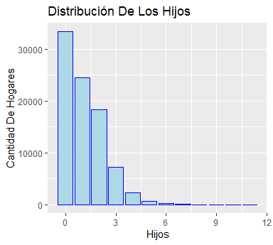

```r
ggplot(datos_sin_conyuge,aes(x=Hijos))+geom_bar(color="blue",fill="lightblue")+labs(title = "Distribución De Los Hijos")+ylab("Cantidad De Hogares")
```

La variable de salida es de tipo numérica discreta, con un rango de entre 0 y 11. Esta variable, al ser discreta, podría considerarse como categórica, pero como observamos en el análisis descriptivo, las salidas no están equilibradas, por lo que para lograr un equilibrio relativo entre las variables, se debería agrupar las categorías de hijos más allá de 3 hijos, pues a partir de aquí, las frecuencias se reducen significativamente. Con un modelo de esta índole, por encima de 3 hijos no se puede especificar la predición, y esto puede ser una pérdida de información importante.

A pesar de esto, el método KNN también puede ser usado para regresión, si tomamos la variable de salida como numérica continua. Esto soluciona el problema de desequilibrio en los datos, pero causa que la salida del modelo sea continua en los reales, pero esto se puede solucionar realizando una aproximación al entero más cercano.

### Método KNN para regresión

Sea $L=\{(\underline{x}_1,y_1),...,(\underline{x}_n,y_n)\}$ un conjunto de tuplas dónde $\underline{x}_i=[x_1^{(i)}...x_p^{(i)}]^T \in R^P$, las cuales son las variables de entrada, y $y_i \in D \subset R$, es la variable de salida.

$\underline{x}_0$ es una nueva tupla de datos de entrada observados. Su imagen $y_0$ se puede predecir calculando el promedio de los $y_i$ de sus $K$ vecinos más cercanos, los cuales se encuentran calculando los $b_i$, que son la distancia entre $\underline{x}_0$ y el $i$-ésimo elemento. Por medio de una regla de distancia, como la euclidiana, es decir $b_i=||\underline{x}_0-\underline{x}_i||_m$, dónde $m$ es una regla, y con $m=2$ tenemos la regla euclidiana.

Luego se ordenan los $b_i$ de menor a mayor

$$b_{(1)}=\min\{b_1,...,b_n\}\\
b_{(2)}=\min\{b_1,...,b_n\}\backslash b_{(1)}\\
\vdots\\
b_{(n-1)}=\min\{b_1,...,b_n\}\backslash\{b_{(1)},b_{(1)},...b_{(n-2)}\}\\
b_{(n)}=\max\{b_1,...,b_n\}\\
b_{(1)}\le b_{(2)}\le ... \le b_{(n)}$$
Y definimos $L_{\underline{x}_0}^K=\{\underline{x}_i \in Z/||\underline{x}_0-\underline{x}_i||_2 \le b_{(K)}\}$ como el conjunto de vecinos más cercanos, dónde $b_{(K)}$ es la distancia entre $\underline{x}_0$ y el $K$-ésimo vecino más cercano.

Finalmente, podemos obtener la observación de $\underline{x}_0$ por medio de una función $f_K(.)$ que se define como:

$$f_K(\underline{x}_0)= \frac {1} {|L_{\underline{x}_0}^K|} \sum y_i,~~y_i/\underline{x}_i \in L_{\underline{x}_0}^K$$
Que no es más que el promedio de las observaciones de los $K$ vecinos más cercanos de $\underline{x}_0$.

Al hablar de una regresión, también podemos considerar el $R^2$, el cual es un coeficiente que nos permite saber qué tan cerca de la línea calculada por el modelo de regresión, se encuentran las verdaderas imágenes de las observaciones que se ingresen. Es un número de 0 a 1 dónde 0 indica que el modelo no explica el comportamiento de los datos, y 1, que los explica de manera perfecta.

#### Programación del modelo

Se escribe una función para crear y entrenar un modelo KNN a partir de un conjunto de datos y un rango de vecinos K para probar

```r
#Creamos función para crear un modelo KNN
crear_modelo_knn <- function(datos_entrenamiento, rango_k_vecinos = 1:25){

  set.seed(42)

  ctrl <- trainControl(
    method="cv", #Entrenamiento con Cross Validation
    number = 5, #Número de divisiones de la validación cruzada
    #verboseIter = TRUE
    )

  modelo_knn <- train(
    Hijos ~ .,
    data = datos_entrenamiento,
    method = "knn",
    trControl = ctrl,
    preProcess = c("center","scale"), #Los datos se normalizan
    tuneGrid = data.frame(k = rango_k_vecinos)
    )

  return(modelo_knn)
}
```

Definimos funciones de utilidad para separar los datos en entrenamiento y validación, generar la matriz de confusión y para evaluar el modelo

```r
# Creamos una función para separar los datos por entrenamiento y validación
separacion_de_datos <- function(datos,split){
  if(missing(split)){
    split<-0.7 #Por defecto se parte 70/30
  }
  indices_de_entrenamiento <- createDataPartition(datos$Hijos, p=split, list=FALSE)
  datos_entrenamiento <- datos[ indices_de_entrenamiento,]
  datos_validacion <- datos[-indices_de_entrenamiento,]
  return(list("entrenamiento" = datos_entrenamiento, "validacion" = datos_validacion))
}

#Creamos una función que nos imprime la matriz de confusión dados el modelo y los datos
matriz_de_confusion <- function(modelo,datos){
  modelo_prediccion <- predict(modelo,newdata = datos )
  print(confusionMatrix(modelo_prediccion, datos$Hijos ))
}

#Función para calcular el MSE y el RMSE a partir de los datos de validación y las predicciones
mse_y_rmse <- function(datos_validacion, predicciones){

  #Calculamos el mínimo error cuadrado (Minimum Square Error)
  mse <-sum((predicciones - datos_validacion$Hijos)^2)/length(datos_validacion$Hijos)

  #Calculamos la raíz del mínimo error cuadrado (Root Minimum Square Error)
  rmse <-sqrt(mse)

  resultados <- data.frame(
    'MSE' =c(mse),
    'RMSE' = c(rmse)
  )
  return(resultados)
}

#Función para evaluar el modelo dados el modelo y los datos de validación
evaluar_modelo <-function(modelo,datos_validacion){
  predicciones <- predict(modelo,newdata = datos_validacion)
  return(predicciones)
}
```

Hacemos uso de las funciones creadas para partir los datos en entrenamiento y validación

```r
#Partimos los datos con la función separacion_de_datos
particion <- separacion_de_datos(datos_finales)

#Separamos por entrenamiento
datos_entrenamiento <- particion$entrenamiento
datos_de_entrada_entrenamiento <- subset(datos_entrenamiento, select = -c(Hijos))

#Separamos por validación
datos_validacion <- particion$validacion
datos_de_entrada_validacion <- subset(datos_validacion, select = -c(Hijos))
```

Finalmente entrenamos el modelo y lo exportamos en un archivo RDS para poder hacer uso de él

```r
#Se comentaron las líneas dónde se crea el modelo para asegurar la reprodcibilidad

#Entrenamos un modelo KNN con la función crear_modelo_knn
# modelo_knn<-crear_modelo_knn(datos_entrenamiento)
# saveRDS(modelo_knn,"./Modelos/knn_modelo.rds")

#Leemos el modelo guardado
carga_modelo_knn <- readRDS("./Modelos/knn_modelo.rds")
```

Al crear el modelo, se hizo una exploración de diferentes valores de K, entre 1 y 25, para encontrar el valor de K óptimo, comparando los diferentes resultados con respecto al RMSE obtenido

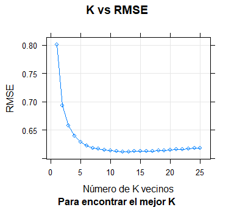

```r
#Buscamos el K óptimo comparándolo con el RMSE
plot(carga_modelo_knn,main = "K vs RMSE", sub='Para encontrar el mejor K', ylab='RMSE', xlab='Número de K vecinos')
```

```r
print(carga_modelo_knn)
```

```
## k-Nearest Neighbors
##
## 60723 samples
##     9 predictor
##
## Pre-processing: centered (20), scaled (20)
## Resampling: Cross-Validated (5 fold)
## Summary of sample sizes: 48578, 48578, 48578, 48579, 48579
## Resampling results across tuning parameters:
##
##   k   RMSE       Rsquared   MAE
##    1  0.8002727  0.5907002  0.4124301
##    2  0.6926261  0.6674666  0.3882218
##    3  0.6572564  0.6941914  0.3804639
##    4  0.6390664  0.7083165  0.3768909
##    5  0.6280605  0.7171285  0.3752877
##    6  0.6224225  0.7215946  0.3752430
##    7  0.6181548  0.7250978  0.3749991
##    8  0.6164144  0.7265140  0.3760768
##    9  0.6147084  0.7279653  0.3766530
##   10  0.6134072  0.7291207  0.3774409
##   11  0.6125649  0.7299189  0.3782726
##   12  0.6118644  0.7306142  0.3791651
##   13  0.6118477  0.7307199  0.3799202
##   14  0.6119434  0.7307385  0.3809207
##   15  0.6119860  0.7308277  0.3818458
##   16  0.6123682  0.7305957  0.3828175
##   17  0.6129352  0.7302072  0.3839682
##   18  0.6132201  0.7300776  0.3850089
##   19  0.6139354  0.7295584  0.3860741
##   20  0.6146770  0.7290230  0.3872012
##   21  0.6153969  0.7285103  0.3882659
##   22  0.6160757  0.7280478  0.3895232
##   23  0.6168708  0.7274450  0.3905760
##   24  0.6173926  0.7270937  0.3914920
##   25  0.6177480  0.7269144  0.3923233
##
## RMSE was used to select the optimal model using the smallest value.
## The final value used for the model was k = 13.
```

El mejor menor valor para los K vecinos del modelo es de 13 con un RMSE de 0.6118477 y un $R^2$ de 0.7307199

```r
#Guardamos los valores para futuras comparaciones
rmse_knn_entrenamiento <- 0.6118477
r2_knn_entrenamiento <- 0.7307199
```

# Resultados

## Comparación con otros modelos

Para poner en contexto el modelo entrenado y sus resultados, se comparará en relación con otros dos modelos diferentes al KNN: *Random Forest* y *Ridge Regression*

### Creacion del modelo Random Forest

El modelo Random Forest es ampliamente conocido por ser uno de los modelos más eficaces a la hora de hacer predicciones. Se basa en la generación de Árboles de Decisión de manera aleatoria, para luego realizar un entrenamiento y validación con los mismos datos de entrenamiento para cada uno de los árboles, para buscar entre ellos al o los que generen mejores resultados. A la par de su alta efectivdad, está su necesidad de alta capacidad de cómputo para generar sus mejores resultados, por lo que para ejercicos de “prueba y error” no es un modelo recomendable si no se cuenta con capacidad de cómputo suficiente. El modelo de Random Forest se definió con el siguiente script:

```r
#Función para crear un modelo de random forest
crear_modelo_random_forest <- function(datos_entrenamiento,datos_entrada_entrenamiento){

  set.seed(42) #Fijamos la semilla para asegurar la reproducibilidad

  ctrl <- trainControl(
    method="cv", #Entrenamiento con validación cruzada
    number=3, #Número de folds
    search="grid",
    #verboseIter = TRUE #Muestra la iteración actual por pantalla
    )

  #Número de ariables seleccionadas para el mtry
  mtry <- ncol(datos_entrada_entrenamiento)/3
  tunegrid <- expand.grid(.mtry=mtry)

  modelo_random_forest <- train(
    Hijos ~ .,
    data = datos_entrenamiento,
    method = 'rf',
    tuneGrid  = tunegrid,
    trControl = ctrl
    )

  return(modelo_random_forest)

}
```

Para evitar problemas por falta de capacidad de cómputo, solo se definió una iteración en el *grid*, definida como el número de columna de los datos de entrada dividido entre 3, que es la más usada por defecto, además de definir un número bajo de *K-Folds* =3

```r
#Se comentaron las líneas dónde se crea el modelo para asegurar la reprodcibilidad

#Entrenamos un modelo random forest con la función crea_modelo_random_forest
# modelo_random_forest<-crear_modelo_random_forest(datos_entrenamiento,datos_de_entrada_entrenamiento)
# saveRDS(modelo_random_forest,"./Modelos/rf_modelo.rds")
carga_modelo_random_forest<-readRDS("./Modelos/rf_modelo.rds")
print(carga_modelo_random_forest)
```

```
## Random Forest
##
## 60723 samples
##     9 predictor
##
## No pre-processing
## Resampling: Cross-Validated (3 fold)
## Summary of sample sizes: 40482, 40481, 40483
## Resampling results:
##
##   RMSE       Rsquared   MAE
##   0.6147983  0.7512361  0.4168389
##
## Tuning parameter 'mtry' was held constant at a value of 3
```

```r
rmse_random_forest_entrenamiento <- 0.6147983
r2_random_forest_entrenamiento <- 0.7512361
print('Diferencia entre RMSE de KNN - Random Forest')
```

```
## [1] "Diferencia entre RMSE de KNN - Random Forest"
```

```r
print(rmse_knn_entrenamiento - rmse_random_forest_entrenamiento)
```

```
## [1] -0.0029506
```

```r
print('Diferencia entre R2 de KNN - Random Forest')
```

```
## [1] "Diferencia entre R2 de KNN - Random Forest"
```

```r
print(r2_knn_entrenamiento - r2_random_forest_entrenamiento)
```

```
## [1] -0.0205162
```

Se puede observar que a pesar de que las métricas del Random Forest son ligeramente superiores, la diferencia no es realmente grande en ninguna de las dos métricas.

### Creacion del modelo Ridge

El modelo *Ridge* es ampliamente utilizado para modelos de regresión. Es especialmente conocido por analizar datos que tengan una alta multicolinealidad. Regulariza sus resultados haciendo uso de la L2 para penalizar los resultados, y así tener resultados menos dispersos. El script para la generación de su modelo es el siguiente:

```r
crear_modelo_ridge <- function(datos_entrenamiento){

  set.seed(42) #Fijamos la semilla para asegurar la reproducibilidad

  #Establecemos los valores de lambda para el modelo (L2)
  parameters <- c(seq(0.01, 0.1, 0.01), seq(0.1, 2, by =0.1) , seq(2, 5, 0.5) )

  ridge<-train(
    Hijos ~ .,
    data = datos_entrenamiento,
    method = 'glmnet',
    tuneGrid = expand.grid(alpha = 0, lambda = parameters),
    metric =  "Rsquared"
    )

  return(ridge)
}
```

Definimos un vector de parámetros $\lambda$ para buscar entre ellos al que mejor penaliza los resultados.

```r
#Se comentaron las líneas dónde se crea el modelo para asegurar la reprodcibilidad

#Entrenamos un modelo Ridge con la función crear_modelo_gridge
# modelo_ridge<-crear_modelo_ridge(datos_entrenamiento)
# saveRDS(modelo_ridge,"./Modelos/ridge_modelo.rds")
carga_modelo_ridge <- readRDS("./Modelos/ridge_modelo.rds")
print(carga_modelo_ridge)
```

```
## glmnet
##
## 60723 samples
##     9 predictor
##
## No pre-processing
## Resampling: Bootstrapped (25 reps)
## Summary of sample sizes: 60723, 60723, 60723, 60723, 60723, 60723, ...
## Resampling results across tuning parameters:
##
##   lambda  RMSE       Rsquared   MAE
##   0.01    0.6723588  0.6771778  0.4906069
##   0.02    0.6723588  0.6771778  0.4906069
##   0.03    0.6723588  0.6771778  0.4906069
##   0.04    0.6723588  0.6771778  0.4906069
##   0.05    0.6723588  0.6771778  0.4906069
##   0.06    0.6723588  0.6771778  0.4906069
##   0.07    0.6723588  0.6771778  0.4906069
##   0.08    0.6723588  0.6771778  0.4906069
##   0.09    0.6723588  0.6771778  0.4906069
##   0.10    0.6728972  0.6770620  0.4914685
##   0.10    0.6728972  0.6770620  0.4914685
##   0.20    0.6841968  0.6747895  0.5068140
##   0.30    0.6982271  0.6720596  0.5231306
##   0.40    0.7133458  0.6690928  0.5396725
##   0.50    0.7286989  0.6660209  0.5558397
##   0.60    0.7437307  0.6629636  0.5712868
##   0.70    0.7581788  0.6599823  0.5858396
##   0.80    0.7721048  0.6570408  0.5995529
##   0.90    0.7852023  0.6542566  0.6121804
##   1.00    0.7976479  0.6515694  0.6239541
##   1.10    0.8094327  0.6489919  0.6349221
##   1.20    0.8205799  0.6465260  0.6451404
##   1.30    0.8311432  0.6441616  0.6546886
##   1.40    0.8411841  0.6418847  0.6636470
##   1.50    0.8505343  0.6397785  0.6718881
##   1.60    0.8594110  0.6377599  0.6796367
##   1.70    0.8679733  0.6357703  0.6870366
##   1.80    0.8759443  0.6339408  0.6938671
##   1.90    0.8835604  0.6321725  0.7003472
##   2.00    0.8908924  0.6304454  0.7065463
##   2.50    0.9223530  0.6230263  0.7326870
##   3.00    0.9476336  0.6169666  0.7532238
##   3.50    0.9683778  0.6119391  0.7698021
##   4.00    0.9855428  0.6077798  0.7833442
##   4.50    1.0001284  0.6042199  0.7947451
##   5.00    1.0126875  0.6011318  0.8044976
##
## Tuning parameter 'alpha' was held constant at a value of 0
## Rsquared was used to select the optimal model using the largest value.
## The final values used for the model were alpha = 0 and lambda = 0.09.
```

El mejor resultado se obtiene con un valor de $\lambda=0.09$

```r
rmse_random_ridge <- 0.6723588
r2_random_ridge <- 0.6771778
print('Diferencia entre RMSE de KNN - Ridge Regresion')
```

```
## [1] "Diferencia entre RMSE de KNN - Ridge Regresion"
```

```r
print(rmse_knn_entrenamiento - rmse_random_ridge)
```

```
## [1] -0.0605111
```

```r
print('Diferencia entre R2 de KNN - Ridge Regresion')
```

```
## [1] "Diferencia entre R2 de KNN - Ridge Regresion"
```

```r
print(r2_knn_entrenamiento - r2_random_ridge)
```

```
## [1] 0.0535421
```

Al igual que con el modelo de *Random Forest* la diferencia entre las métricas obtenidas en los modelos de *Ridge Regresion* y *KNN* no es muy amplia, incluso podemos observar que el $R^2$ en el método de *KNN* es ligeramente superior

## Evaluación de datos de validación

Para comprobar la efectividad del modelo, hacemos usode la función *evaluar_modelo* para obtener los resultados

```r
#Evaluamos el modelo con los datos de validación
resultados_validacion<-evaluar_modelo(carga_modelo_knn,datos_de_entrada_validacion)
```

Calculamos el MSE y el RMSE del modelo con los datos de validación y comparamos el RMSE de validación contra el de entrenamiento

```r
#Almacenamos las métricas de error MSE y RMSE para los datos de validación
metricas_de_error_knn<-mse_y_rmse(datos_validacion,resultados_validacion)
#Mostramos las métricas
kable(metricas_de_error_knn, caption='MSE y RMSE para los datos de validación')
```

MSE y RMSE para los datos de validación

| MSE | RMSE |
| --- | --- |
| 0.3311276 | 0.5754369 |

```r
#Comparamos el RMSE de validación con el de entrenamiento
kable(metricas_de_error_knn['RMSE']-rmse_knn_entrenamiento, caption = 'Diferencia RMSE de validación - de entrenamiento', col.names = c('Diferencia RMSE'))
```

Diferencia RMSE de validación - de entrenamiento

| Diferencia RMSE |
| --- |
| -0.0364108 |

Podemos observar que el valor del RSME de validación es ligeramente menor que con los datos de entrenamiento.

Aprovechando los modelos ya generados de *Ridge Regresion* y *Random Forest*, los usamos para comparar los resultados con los datos de validación

```r
#Generamos resultados a partir de los datos de validación para el modelo de Ridge Regresion
resultados_validacion_ridge<-evaluar_modelo(carga_modelo_ridge,datos_de_entrada_validacion)

#Generamos las métricas de error para el modelo Ridge con los datos de validación
metricas_de_error_ridge<-mse_y_rmse(datos_validacion,resultados_validacion_ridge)
kable(metricas_de_error_ridge, caption='MSE y RMSE para los datos de validación')
```

MSE y RMSE para los datos de validación

| MSE | RMSE |
| --- | --- |
| 0.4519479 | 0.6722707 |

```r
#Calculamos la diferencia entre las métricas con el método KNN y el método Ridge
kable(metricas_de_error_knn-metricas_de_error_ridge, caption = 'Diferencia métricas con datos de validación (KNN - Ridge Regresion)', col.names = c('Diferencia MSE','Diferencia RMSE'))
```

Diferencia métricas con datos de validación (KNN - Ridge Regresion)

| Diferencia MSE | Diferencia RMSE |
| --- | --- |
| -0.1208203 | -0.0968338 |

Podemos observar que el error del modelo KNN empieza a ser significativamente menor con los datos de validación, en comparación con el modelo de *Ridge Regresion*

Realizamos el mismo proceso con el modelo *Random Forest*

```r
# Evaluación de los datos de validación con Random Forest
resultados_validacion_random_forest<-evaluar_modelo(carga_modelo_random_forest,datos_de_entrada_validacion)

#Generamos las métricas MSE y RMSE para el modelo de Random Forest
metricas_de_error_random_forest<-mse_y_rmse(datos_validacion,resultados_validacion_random_forest)
kable(metricas_de_error_random_forest, caption='MSE y RMSE para los datos de validación')
```

MSE y RMSE para los datos de validación

| MSE | RMSE |
| --- | --- |
| 0.3264549 | 0.5713623 |

```r
#Calculamos la diferencia entre las métricas con el método KNN y el método Random Forest
kable(metricas_de_error_knn-metricas_de_error_random_forest, caption = 'Diferencia métricas con datos de validación (KNN - Random Forest)', col.names = c('Diferencia MSE','Diferencia RMSE'))
```

Diferencia métricas con datos de validación (KNN - Random Forest)

| Diferencia MSE | Diferencia RMSE |
| --- | --- |
| 0.0046727 | 0.0040746 |

Aunque las métricas de error son superiores para el modelo KNN, la diferencia no es tan significativa

# Conclusiones

El modelo también fue comparado con otros dos modelos, el *Random Forest*, reconocido por ser uno de los más certeros, y el *Ridge Regresion*, ampliamente utilizado en modelos de regresión. Se pudo observar que las métricas tanto en la fase de entrenamiento, como en las de validación, para todos los modelos no eran significativamente diferentes. A pesar de ser el *Random Forest* el modelo más certero, los resultados del modelo KNN no se alejaron mucho. Por otra parte, en comparación con el modelo *Ridge Regresion*, KNN llegó a ser ligeramente superior en el entrenamiento, y empezó a ser significativamente superior con los datos de validación.

Los resultados obtenidos de manera individual y las comparativas con otros modelos nos permiten determinar que el modelo construído permite obtener una predicción precisa ycercana a la realidad de la cantidad de hijos de los hogares en Colombia, conociendo datos del hogar como lo son: La edad del Jefe del hogar, la cantidad de personas de componen el hogar, El número de cuartos que destinan para dormir, los ingresos económicos totales de la familia, el valor que pagan por la factura de la electricidad mensualmente, el estado civil, la ocupación, el acceso a internet, el sexo y el nivel de educación del jefe de familia.

## Creacion del modelo con todos los datos

El siguiente script genera un modelo final con todos los datos, tanto de entrenamiento, como de validación, y sirve para la puesta en marcha del algoritmo en un ambiente de producción

```r
# knn_modelo_final<-crear_modelo_knn(datos_finales,10:18)
# saveRDS(knn_modelo_final,"./Modelos/knn_modelo_final.rds")
```

# Enlaces del proyecto

- [GitHub](https://github.com/juanescendales/TAE-01-NatalidadColombia)
- [Rpub](https://rpubs.com/Alexitouno19/TAE-01-NatalidadColombia)
- [Shiny](https://alemando.shinyapps.io/TAE-Numero-Hijos/)
- video explicativo del modelo

# Bibliografía

Alvis-Guzmán, N., Yánez-Contreras, M., Quejada-Pérez, R., Acevedo-González, K., & Del Río-Carrasquilla, F. (2010). Fecundidad y participación de la mujer en el mercado laboral en la Costa Caribe y en Colombia. Revista Gerencia y Políticas de Salud, 9(19), 90-107. Retrieved April 04, 2021, from http://www.scielo.org.co/scielo.php?script=sci_arttext&pid=S1657-70272010000200007&lng=en&tlng=es.

Forero, N., & Gamboa, L. F. (2009). Family Size in Colombia: Guessing or Planning? Intended vs. Actual Family Size in Colombia. Desarrollo y Sociedad, (64), 85-118. Retrieved April 04, 2021, from http://www.scielo.org.co/scielo.php?script=sci_arttext&pid=S0120-35842009000200004&lng=en&tlng=en.

López, Á. R., Silva, A. C., & Sarmiento, J. A. (2014). Autonomía femenina y factores asociados al uso de servicios maternos en Colombia (2010). Revista Latinoamericana de Ciencias Sociales, Niñez y Juventud, 12(1), 325-337. https://doi.org/10.11600/1692715x.12119081413

Pachón, X. (2004). La familia en Colombia a lo largo del siglo XX [Ebook] (1st ed., pp. 145,159). Bogotá: Universidad Nacional de Colombia. Retrieved from https://www.studocu.com/co/document/universidad-de-pamplona/sociedad-familia-y-salud/resumenes/la-familia-en-colombia-a-lo-largo-del-siglo-xx/8981874/view

Torres Tabares, C. M., & Vergara MUñoz, E. C. (2012). Características sociodemográficas de personas sometidas a esterilización quirúrgica (Medellín 2006-2010) (Sociodemographic characteristics of people subjected to surgica l sterilization (Medellín 2006-2010)). CES Salud Pública, 3(2), 129-140. https://doi.org/10.21615/1841